# Project 2

STATS 220 Semester One 2023

Rudklao Raviyan UPI 2590622

2023-03-26

## Introduction

As a person whose first language is not English, I am interested on how my peers learn new language and what methods they use to learn a new language. I remembered when I learn my third language, I faced with many challenges as I cannot learn and use the new language effectively. Here is my [link](https://docs.google.com/forms/d/e/1FAIpQLSf-_JloieYxlaIoq9twVRIikIAv2gDmlVUOiMjOvW9yTCGG4w/viewform) to my survey :)

For this project, I shared my survey with my friends and families whose majority lived outside of New Zealand, therefore I placed importance on communicating my purpose of the survey. They may not understand the context of this project clearly in contrast to participants that may come from my class mate who is taking Stats 220 course. I clearly stated why I collect this data so that my participants and why I collect them. Another important aspect is that I clearly stated that their participation will remain anonymous and data collected will be shared among the Stats 220 teaching staff and students only. The main reason that to protect their privacy. In addition, I also put my contact detail so that the participants can contact me directly if they have any further questions.

In this survey, I collected data through various form of questions including, multiple choices, short answer questions, check boxes with fixed options. One challenge faced when processing the data is that the data collected through check boxes are not tidy. This is because in that particular question, the participant can select more than one answers. According to Third Normal Form approach for relational databases, each cell should contain a single value. However, from the Google form spreadsheet, the question that uses check boxes will contain multiple values in a single cell. When processing that data, I needed to do “data cleaning” where I needed to separate the responses with comma so that I can do further analysis. This is contrast to other responses collected through multiple choices where I can directly process the data without having to clean them (or do additional r command to process the data).

## Analytics

```
## Rows: 20
## Columns: 8
## $ Timestamp        <chr> "25/03/2023 12:54:10", "25/03/2023 12:57:33", "25/03/…
## $ first_language   <chr> "Thai", "Tongan", "English", "Thai", "Thai", "English…
## $ language_speak   <dbl> 3, 2, 2, 3, 2, 2, 2, 3, 2, 3, 2, 3, 2, 2, 2, 3, 3, 1,…
## $ learn_new_lang   <chr> "No", "No", "No", "No", "No", "Yes", "Yes", "No", "No…
## $ time_learning    <dbl> 30, 0, 30, 180, 10, 20, 60, 0, 60, 0, 60, 60, 120, 3,…
## $ learning_method  <chr> "Listening", "Speaking", "Listening", "Listening", "S…
## $ resources        <chr> "Going to a class, Using mobile learning application,…
## $ memorized_method <chr> "Use in the daily routines", "Use in the daily routin…
```

From this survey, there are **20** participants in this survey. The background information collected from this data included, the maximum number of language spoken by a participant is **3**. The first languages of the participants are including **Thai, Tongan, English, Chinese/Mandarin, Chinese, Cantonese**.

Among the total participants, there are **7** people who is currently learning a new language. The average time spend in learning a new language is **49 minutes** where the maximum time spend learning a new language is **180 minutes**.

The *Chart 1* shows the resources used by the participants to learn new languages. *Chart 2* shows the most preferred method to memorize new vocabulary and *Chart 3* shows the most preferred methods to learn a new language.

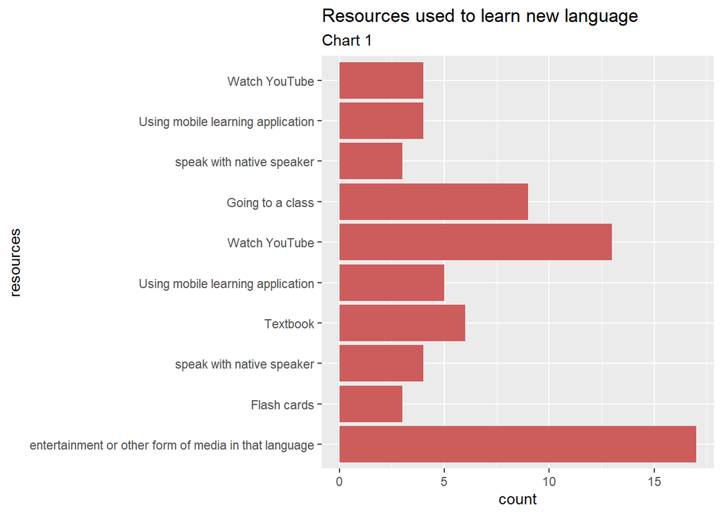

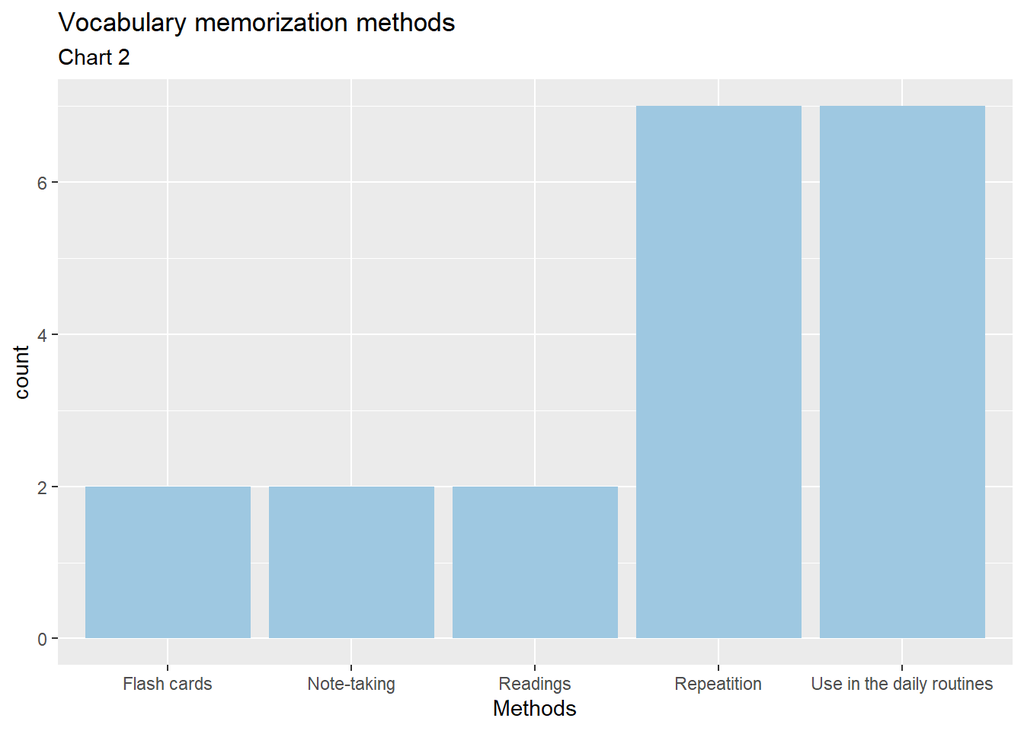

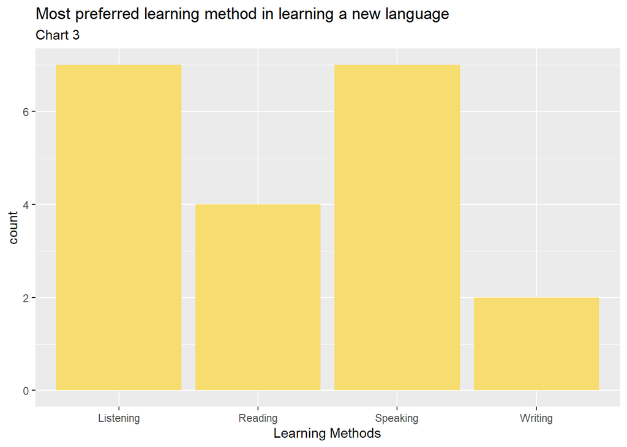

## Reflection

From this project, the important idea I learnt is the data collection process design especially at the survey form design. This is because the data collected from this process will impact on how useful the data to the questions of interests. The major flaw in this project is my data collection process and the questions that I used to collect data. In order to create a dynamic report, I needed to be able to process my data to be insightful and informative to the reader which was very difficult due to the way by data collected. Therefore, I needed to be creative on how I process my data and make the most of the data I got. I had to do further Google search on how to process categorical data and find a way to display the data in the report.

This flaw actually important and it reflects real-life situation in many research where the initial research data collection design may not be effective and problems could arises at much later stage post-data collection. Hence it is important to know on how to draw the most information out of it. Therefore, I am interested to know more on data cleaning and data collection process using technology.